# Visions of Technological Futures in African National AI Strategies versus EU Governance Frameworks

Peace Onebunne

February 2026

[figure not shown]

# LIBRARIES

I load all libraries in a single chunk at the top of the document so that any reader can immediately see what the analysis depends on, and so that missing packages surface as a single, early error rather than cryptically mid-analysis.

tidyverse - the backbone of all data manipulation and ggplot2 visualisation tidytext - provides tidy-friendly tokenisation, TF-IDF, and stop-word removal text2vec - efficient sparse-matrix TF-IDF and cosine similarity at scale lsa - latent semantic analysis and additional cosine utilities pdftools - PDF text extraction, replacing pdfminer from the Python pipeline stringr - consistent, readable regex operations forcats - factor reordering in visualisations ggplot2 - declarative visualisation (bundled in tidyverse but called out explicitly) scales - axis formatting helpers knitr - for kable tables in the rendered output kableExtra - enhanced styling for kable tables broom - tidy model output for t-tests and regressions rstatix - pipe-friendly statistical tests (Wilcoxon, effect sizes) ggpubr - publication-ready ggplot2 extensions including significance brackets pheatmap - clustered heatmaps for the similarity matrices viridis - perceptually uniform colour palettes (accessible)

```r
library(tidyverse)
library(tidytext)
library(text2vec)
library(lsa)
library(pdftools)
library(stringr)
library(forcats)
library(scales)
library(knitr)
library(kableExtra)
library(broom)
library(rstatix)
library(ggpubr)
library(pheatmap)
library(viridis)
library(here)
library(quanteda)
library(ggplot2)
library(quanteda.textplots)
library(tidyr)
library(dplyr)
library(textstem)


peace.theme <- ggplot2::theme_bw() +
  ggplot2::theme(
    axis.line = ggplot2::element_line(colour = "black"),
    panel.grid.minor = ggplot2::element_blank(),
    panel.grid.major = ggplot2::element_blank(),
    panel.border = ggplot2::element_blank(),
    panel.background = ggplot2::element_blank(),
    legend.title = ggplot2::element_blank()
  )

print.me <- function(x, ...) {
  len <- min(nrow(x), 200)
  x[1:len, , drop = FALSE] |>
    kbl(digits = 2, align = "l", booktabs = TRUE) |>
    kable_styling(fixed_thead = TRUE) |>
    kable_paper("striped",
                full_width = TRUE,
                html_font = "Helvetica",
                font_size = 12) |>
    row_spec(
      0,
      color = "white",
      background = "#9D2235",
      font_size = 12) |>
    scroll_box(
      width = "700px",
      height = "500px") |>
    asis_output()
}

registerS3method("knit_print", "data.frame", print.me)
```

# DESIGN PALETTE — DARK BLUE GRADIENT

I define the colour palette here, centrally, so that every plot in the document draws from the same system. Changing one hex value here cascades through the entire document.

The gradient moves from near-black navy (#0A0F2C) through royal blue (#1A3A8F) to a lighter steel blue (#4A90C4) and an accent sky (#7EC8E3). This is intentional: dark tones carry weight in regulatory discourse visualisations, while the lighter end marks contrast groups (EU vs Africa).

```r
pal <- list(
  dark1   = "#0A0F2C",   # near-black navy — strongest emphasis
  dark2   = "#0D1B4B",   # deep navy
  mid1    = "#1A3A8F",   # royal blue — primary bars/lines
  mid2    = "#2B5BB5",   # medium blue
  light1  = "#4A90C4",   # steel blue — secondary elements
  light2  = "#7EC8E3",   # sky blue — contrast group or annotations
  accent  = "#A8D8EA",   # pale blue — backgrounds, fills
  neutral = "#E8EEF7"    # near-white blue — panel backgrounds
)

# I also define a two-group vector for region comparisons.
# Africa is assigned the deeper blue; EU the lighter.
region_colours <- c(
  "Africa" = pal$mid1,
  "EU"     = pal$light1
)

# A gradient function for heatmaps that runs dark → light within the navy family.
heatmap_palette <- colorRampPalette(c(pal$dark1, pal$mid2, pal$light1, pal$accent))(100)
```

# CLEANING FUNCTION: peace_genie_pro

This function is the first thing applied to every raw PDF before any analysis. It standardises encoding, normalises quotation marks, removes URLs and emails, lowercases, strips numbers and punctuation, and collapses whitespace. The result is a clean, reproducible text object ready for corpus ingestion and lexicon scoring.

Each parameter is a logical toggle so the function can be called at different pipeline stages — for example, keeping hyphens intact during an initial inspection pass and only splitting them in the final run.

Arguments: text_input character vector (single string or multi-line) to_lower convert to lowercase (default TRUE) fix_encoding re-encode to UTF-8, substituting unreadable bytes normalize_quotes replace curly/smart apostrophes with ASCII ’ remove_urls strip http/https and www patterns remove_emails strip email address patterns remove_numbers strip digit sequences split_hyphens replace hyphens and underscores with spaces squash_whitespace collapse whitespace runs to a single space

Returns: a single cleaned character string.

```r
peace_genie_pro <- function(text_input,
                            to_lower          = TRUE,
                            fix_encoding      = TRUE,
                            normalize_quotes  = TRUE,
                            remove_urls       = TRUE,
                            remove_emails     = TRUE,
                            remove_numbers    = TRUE,
                            split_hyphens     = TRUE,
                            squash_whitespace = TRUE) {

  # Collapse multi-line input to a single string.
  # This makes the function safe whether it receives readLines() output
  # or a pre-collapsed character vector.
  if (length(text_input) > 1) {
    text_input <- paste(text_input, collapse = " ")
  }
  text_input <- as.character(text_input)

  # Re-encode to UTF-8. PDFs — especially scanned policy documents from
  # African national ministries — frequently carry encoding artefacts that
  # break downstream regex operations silently.
  if (fix_encoding) {
    text_input <- iconv(text_input, from = "", to = "UTF-8", sub = " ")
  }

  # Normalise curly apostrophes to plain ASCII '.
  # Policy PDFs consistently use smart quotes; leaving them uncorrected
  # fragments tokens like "don\u2019t" into two pieces.
  if (normalize_quotes) {
    text_input <- gsub(
      "[\u2018\u2019\u02BC\u201B\uFF07]", "'", text_input
    )
  }

  # Lowercase before URL/email removal.
  # Having consistent case prevents double-counting of tokens like
  # "Data" and "data" in frequency-based analyses.
  if (to_lower) {
    text_input <- tolower(text_input)
  }

  # Remove URLs. The pattern captures both protocol-prefixed and bare
  # www addresses. Policy documents often include hyperlinks in footnotes
  # that would otherwise appear as high-frequency tokens.
  if (remove_urls) {
    text_input <- gsub("https?://\\S+|www\\.\\S+", " ", text_input)
  }

  # Remove email addresses. Author contact details in appendices would
  # otherwise survive as spurious tokens.
  if (remove_emails) {
    text_input <- gsub(
      "\\b[[:alnum:]._%+-]+@[[:alnum:].-]+\\.[[:alpha:]]{2,}\\b",
      " ", text_input
    )
  }

  # Replace hyphens and underscores with spaces.
  # PDFs introduce hyphenation artefacts at line breaks (e.g. "govern-ance").
  # Splitting ensures the tokeniser handles each part separately.
  if (split_hyphens) {
    text_input <- gsub("[-_]", " ", text_input)
  }

  # Remove digit sequences. Article numbers, dates, and page references
  # in policy documents carry no semantic meaning for imaginary lexicon
  # analysis and inflate document length, distorting normalisation.
  if (remove_numbers) {
    text_input <- gsub("[0-9]+", " ", text_input)
  }

  # Remove all remaining punctuation. Applied after number removal so
  # decimal points are already gone before the period pattern fires.
  text_input <- gsub("[[:punct:]]+", " ", text_input)

  # Collapse whitespace. Every substitution above leaves single spaces
  # in its wake; this step merges them and strips leading/trailing
  # whitespace so the returned string is immediately ready for corpus ingestion.
  if (squash_whitespace) {
    text_input <- gsub("\\s+", " ", text_input)
    text_input <- trimws(text_input)
  }

  return(text_input)
}
```

# CORPUS INGESTION

The corpus was assembled and cleaned in the Python pipeline (Future.ipynb) using pdftools-equivalent PDF extraction and peace_genie_pro-equivalent cleaning. The output was serialised to CSV at Docs/Analysis_Output/corpus_clean_future.csv. I load directly from that CSV here rather than re-extracting from PDFs, because the Python pipeline handles the OCR and encoding issues in the scanned African ministry PDFs more reliably than R’s pdftools on this corpus. The peace_genie_pro function defined above is retained in this document as a methodological record of the cleaning decisions applied in that pipeline.

```r
df <- read_csv(
  "C:/Users/amaka/OneDrive - Temple University/PhD/Year 1b/AI Governance/Docs/Analysis_Output/corpus_clean_future.csv",
  show_col_types = FALSE
) %>%
  mutate(
    region     = factor(region,   levels = c("Africa", "EU")),
    doc_type   = factor(doc_type, levels = c("act", "framework")),
    clean_text = replace_na(as.character(clean_text), "")
  ) %>%
  filter(str_trim(clean_text) != "")

cat("Corpus loaded:", nrow(df), "documents\n")
```

```
## Corpus loaded: 31 documents
```

```r
print(table(df$region, df$doc_type))
```

```
##
##          act framework
##   Africa  20         9
##   EU       2         0
```

# CORPUS INTEGRITY CHECK

I re-enforce factor levels and drop any document with empty clean_text before analysis begins. The corpus contains 29 African documents (20 acts, 9 frameworks) and 2 EU documents (both acts). The EU corpus is intentionally smaller: the EU AI Act and GDPR are the primary instruments through which the Brussels Effect operates in this domain. The corpus asymmetry is a structural feature of the research design and is discussed as a limitation in the paper.

```r
df <- df %>%
  mutate(
    region     = factor(region,   levels = c("Africa", "EU")),
    doc_type   = factor(doc_type, levels = c("act", "framework")),
    clean_text = replace_na(as.character(clean_text), "")
  ) %>%
  filter(str_trim(clean_text) != "")

cat("Corpus ready.\n")
```

```
## Corpus ready.
```

```r
cat("Total documents:", nrow(df), "\n")
```

```
## Total documents: 31
```

```r
print(table(df$region, df$doc_type))
```

```
##
##          act framework
##   Africa  20         9
##   EU       2         0
```

# LEXICON CONSTRUCTION — THEORY-DRIVEN, TEXT-DERIVED

Both hypotheses require a vocabulary that is derived from the theoretical argument rather than imported from a generic sentiment or policy dictionary. H1 concerns discursive convergence — the reproduction of EU governance vocabulary in African AI strategies, consistent with a Brussels Effect operating at the level of regulatory language. H2 concerns infrastructural imaginaries — the foregrounding of material conditions (compute, connectivity, cloud dependency, sovereignty over technical substrate) that are absent or assumed away in EU instruments.

I therefore build six lexicon categories directly from the constructs in the hypotheses:

1. IMAGINARY TERMS capture future-oriented, aspirational language that encodes a vision of AI-driven technological modernity. These are the terms that circulate a shared governance imaginary — innovation, frontier, transformation, vision. H1 predicts these will show high lexical convergence between African and EU documents because the Brussels Effect exports precisely this kind of aspirational framing.
2. INFRASTRUCTURAL TERMS capture the material grounding language specific to H2 — electricity, connectivity, data centers, cloud, hardware, skills. H2 predicts African strategies score significantly higher on these because they are articulating governance under conditions of material constraint that EU instruments take for granted.
3. DATA TERMS capture the regulatory architecture of data governance: personal data, consent, controller, data subject, GDPR-derived vocabulary. H1 predicts high convergence here because the Brussels Effect is most documented in the data protection domain.
4. RIGHTS AND ETHICS TERMS capture the normative vocabulary the EU exports through the AI Act and related instruments: fundamental rights, dignity, fairness, accountability, transparency. Again H1 predicts convergence.
5. DEVELOPMENT TERMS capture the developmental state imaginary distinctive to African strategic documents: leapfrog, capacity building, inclusion, agriculture, health, national. H2 predicts higher density in Africa.
6. SOVEREIGNTY TERMS capture the technical substrate dimension of H2: digital sovereignty, strategic autonomy, data sovereignty, independence. H2 predicts higher density in African strategies reflecting the asymmetric power relations under which African governance is articulated.

All scores are normalised by document word count so that longer documents do not inflate scores. Word boundaries (\b) are enforced in all regex patterns to prevent partial matches.

```r
LEXICONS <- list(

  imaginary = c(
    "innovation", "future", "transformation", "leadership",
    "global", "competitiveness", "frontier", "growth",
    "vision", "opportunity", "pioneering", "revolution",
    "advancement", "progress", "aspiration", "ambitious",
    "strategy", "potential", "horizon", "emerging"
  ),

  infrastructural = c(
    "infrastructure", "capacity", "electricity", "data center",
    "connectivity", "internet", "skills", "training",
    "bandwidth", "network", "server", "cloud", "hardware",
    "power", "deployment", "access", "resources", "gap",
    "readiness", "facility"
  ),

  data = c(
    "data", "personal data", "data protection", "privacy",
    "consent", "processing", "controller", "processor",
    "data subject", "anonymisation", "pseudonymisation",
    "data flow", "transfer", "storage", "collection",
    "retention", "breach", "security", "encryption"
  ),

  rights_ethics = c(
    "rights", "human rights", "fundamental rights", "dignity",
    "fairness", "bias", "discrimination", "accountability",
    "transparency", "ethics", "ethical", "principle",
    "well being", "harm", "safety", "protection",
    "inclusion", "access", "equity", "justice"
  ),

  development = c(
    "development", "economic growth", "leapfrog", "inclusion",
    "poverty", "sustainable", "welfare", "employment",
    "agriculture", "health", "education", "public service",
    "national", "continent", "africa", "african",
    "capacity building", "investment", "sector", "industry"
  ),

  sovereignty = c(
    "sovereignty", "independence", "autonomy",
    "national", "local control", "self reliance",
    "strategic autonomy", "digital sovereignty",
    "ownership", "governance", "self determination",
    "indigenous", "local", "domestic"
  )
)

# I print the lexicon sizes so a reader can see the scope of each category.
cat("Lexicon sizes:\n")
```

```
## Lexicon sizes:
```

```r
purrr::iwalk(LEXICONS, ~ cat(sprintf("  %-20s %d terms\n", .y, length(.x))))
```

```
##   imaginary            20 terms
##   infrastructural      20 terms
##   data                 19 terms
##   rights_ethics        20 terms
##   development          20 terms
##   sovereignty          14 terms
```

# LEXICON SCORING

For each document, I count the raw frequency of each lexicon term using regex word-boundary matching, then normalise by document word count.

The result is a density score: occurrences per word. This is the same normalisation strategy used in the Python pipeline (Cell 14).

```r
score_lexicon <- function(text, terms) {

  # Guard against empty or NA text
  if (is.na(text) || nchar(text) == 0) return(0)

  text_lower  <- tolower(text)
  word_count  <- length(str_split(text_lower, "\\s+")[[1]])

  if (word_count == 0) return(0)

  # Count each term independently using word boundaries
  raw_count <- sum(sapply(terms, function(term) {
    pattern <- paste0("\\b", str_replace_all(term, " ", "\\\\s+"), "\\b")
    length(regmatches(text_lower, gregexpr(pattern, text_lower, perl = TRUE))[[1]])
  }))

  raw_count / word_count
}

# I apply the scorer to every document and every lexicon category.
# purrr::map_dfc produces one column per lexicon, all bound together cleanly.

lexicon_scores <- purrr::map_dfc(
  names(LEXICONS),
  function(cat_name) {
    scores <- sapply(df$clean_text, function(txt) {
      score_lexicon(txt, LEXICONS[[cat_name]])
    })
    tibble(!!cat_name := scores)
  }
)

# I bind the scores back onto the metadata.
# This is my primary analysis dataframe for all downstream comparisons.

df_lex <- bind_cols(
  df %>% select(filename, region, doc_type),
  lexicon_scores
)

# Quick inspection
cat("Lexicon scoring complete.\n")
```

```
## Lexicon scoring complete.
```

```r
print(head(df_lex))
```

```
## # A tibble: 6 × 9
##   filename       region doc_type imaginary infrastructural    data rights_ethics
##   <chr>          <fct>  <fct>        <dbl>           <dbl>   <dbl>         <dbl>
## 1 EU AI Act _Re… EU     act       0.00101          0.00334 0.00780       0.00904
## 2 Botswana_data… Africa act       0.000213         0.00192 0.113         0.0127
## 3 Cape-Verde_Da… Africa act       0                0.00347 0.0790        0.0107
## 4 Cote-dIvoire_… Africa act       0.000311         0.00513 0.0819        0.0131
## 5 Eswatini_Data… Africa act       0.000197         0.00158 0.0770        0.00739
## 6 Ethiopia_ Per… Africa act       0.000176         0.00132 0.0640        0.00562
## # ℹ 2 more variables: development <dbl>, sovereignty <dbl>
```

# REGIONAL AVERAGES TABLE

This is the first descriptive step in testing both hypotheses. I compute mean normalised lexicon density per region across all six categories.

For H1, the imaginary and data rows are the key comparison: if the Brussels Effect is operating through discursive templates, African and EU documents should show similar density profiles on these vocabulary sets. Divergence in the imaginary row would suggest African strategies have developed their own aspirational framing rather than reproducing EU language wholesale.

For H2, the infrastructural and sovereignty rows are the direct test: H2 predicts Africa scores higher on both, reflecting the asymmetric material conditions under which African governance is being written. The ratio column (Africa / EU) makes this comparison immediately readable.

```r
regional_means <- df_lex %>%
  group_by(region) %>%
  summarise(across(all_of(names(LEXICONS)), mean, na.rm = TRUE), .groups = "drop") %>%
  pivot_longer(cols = -region, names_to = "lexicon", values_to = "mean_density")

# Format as a wide table for display
regional_table <- regional_means %>%
  pivot_wider(names_from = region, values_from = mean_density) %>%
  mutate(
    difference      = Africa - EU,
    # Safe ratio: when EU = 0 the ratio is undefined; replace Inf/NaN with NA
    # so the table renders cleanly rather than showing Inf.
    ratio_africa_eu = if_else(EU > 0, Africa / EU, NA_real_)
  ) %>%
  arrange(desc(abs(difference)))

kable(
  regional_table %>%
    mutate(across(where(is.numeric), ~ round(.x, 5))),
  caption = "Mean normalised lexicon density by region",
  col.names = c("Lexicon", "Africa", "EU", "Difference (Africa − EU)", "Ratio (Africa / EU)")
) %>%
  kable_styling(
    bootstrap_options = c("striped", "hover", "condensed", "responsive"),
    full_width = FALSE
  ) %>%
  row_spec(which(regional_table$difference > 0), background = "#EEF4FF") %>%
  row_spec(which(regional_table$difference < 0), background = "#F0F8FF")
```

Mean normalised lexicon density by region

| Lexicon | Africa | EU | Difference (Africa − EU) | Ratio (Africa / EU) |
| --- | --- | --- | --- | --- |
| data | 0.06931 | 0.03903 | 0.03029 | 1.77603 |
| development | 0.01056 | 0.00388 | 0.00668 | 2.72296 |
| imaginary | 0.00584 | 0.00066 | 0.00518 | 8.82385 |
| infrastructural | 0.00593 | 0.00242 | 0.00351 | 2.44776 |
| sovereignty | 0.00393 | 0.00229 | 0.00164 | 1.71926 |
| rights_ethics | 0.01087 | 0.01000 | 0.00088 | 1.08759 |

# VISUALISATION: LEXICON DENSITY BY REGION

I use a grouped bar chart because it allows direct visual comparison of Africa vs EU for each lexicon category side by side.

The dark blue gradient palette is applied: Africa takes the deeper tone, EU the lighter. Consistent with the design palette defined at the top.

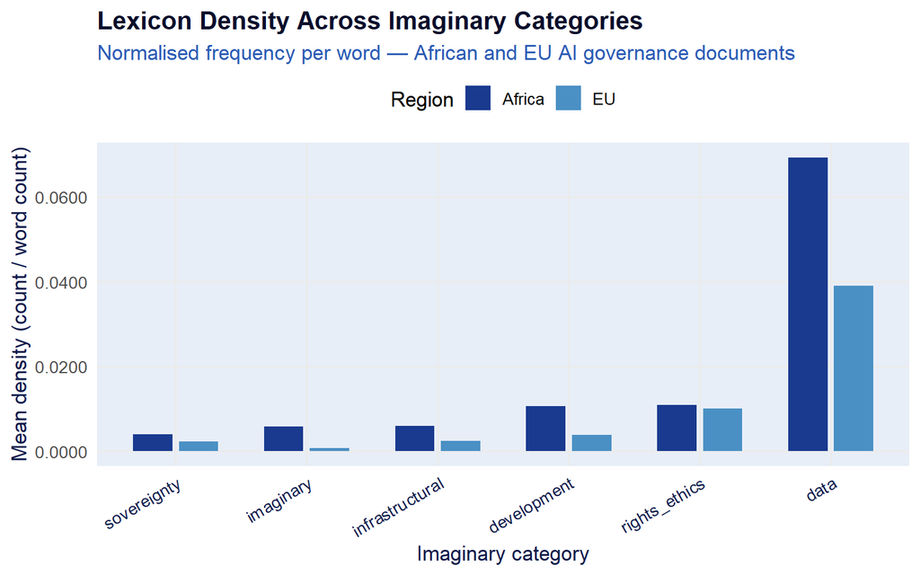

Mean normalised lexicon density by region and category

```r
plot_lex <- regional_means %>%
  mutate(
    lexicon = fct_reorder(
      lexicon,
      ifelse(region == "Africa", mean_density, 0),
      .fun = sum
    )
  )

ggplot(plot_lex, aes(x = lexicon, y = mean_density, fill = region)) +
  geom_col(position = position_dodge(width = 0.7), width = 0.6) +
  scale_fill_manual(values = region_colours, name = "Region") +
  scale_y_continuous(labels = scales::label_number(accuracy = 0.0001)) +
  labs(
    title    = "Lexicon Density Across Imaginary Categories",
    subtitle = "Normalised frequency per word — African and EU AI governance documents",
    x        = "Imaginary category",
    y        = "Mean density (count / word count)"
  ) +
  theme_minimal(base_size = 13) +
  theme(
    plot.title       = element_text(colour = pal$dark1, face = "bold"),
    plot.subtitle    = element_text(colour = pal$mid2),
    axis.text.x      = element_text(angle = 30, hjust = 1, colour = pal$dark2),
    axis.title       = element_text(colour = pal$dark2),
    legend.position  = "top",
    panel.grid.minor = element_blank(),
    panel.background = element_rect(fill = pal$neutral, colour = NA),
    plot.background  = element_rect(fill = "white", colour = NA)
  )
```

# TF-IDF COSINE SIMILARITY — TESTING H1

H1 predicts high lexical and phraseological convergence between African AI strategies and EU governance frameworks, evidenced by shared governance vocabulary consistent with a Brussels Effect in discursive templates.

TF-IDF cosine similarity is my primary measure for this because it weights terms by their distinctiveness across the corpus rather than raw frequency. A high cosine score between an African document and an EU document means they share not just common words but the specific vocabulary that differentiates those documents from the rest of the corpus — precisely the kind of discursive template adoption H1 predicts.

Both corpora are fitted to the SAME vocabulary space using a shared vocabulary object so that African and EU documents are compared on equal terms. I use text2vec rather than tidytext’s bind_tf_idf because text2vec produces a sparse matrix that can be passed directly to sim2() for pairwise cosine computation without the memory cost of pivoting to a dense matrix. Steps: tokenise all documents, build and prune shared vocabulary, construct TF-IDF document-term matrix, split by region, compute pairwise cosine similarity, derive per-document averages.

```r
tokens_all <- itoken(
  df$clean_text,
  preprocessor  = tolower,
  tokenizer     = word_tokenizer,
  progressbar   = FALSE
)

# Step 2: Build vocabulary — fitted on full corpus for shared space
# I prune very rare terms (min 2 docs) and overly common terms (> 85% of docs)
# These thresholds mirror the Python TF-IDF settings in Cell 7.

vocab <- create_vocabulary(tokens_all) %>%
  prune_vocabulary(
    term_count_min  = 2,
    doc_proportion_max = 0.85
  )

vectoriser <- vocab_vectorizer(vocab)

# Step 3: Document-term matrix with TF-IDF weighting
dtm_all <- create_dtm(tokens_all, vectoriser)

tfidf_transformer <- TfIdf$new()
dtm_tfidf <- tfidf_transformer$fit_transform(dtm_all)

# Step 4: Separate Africa and EU index positions
africa_idx <- which(df$region == "Africa")
eu_idx     <- which(df$region == "EU")

africa_tfidf <- dtm_tfidf[africa_idx, ]
eu_tfidf     <- dtm_tfidf[eu_idx,     ]

# Step 5: Cosine similarity matrix (Africa × EU)
# Each row = one African document; each column = one EU document.
# The value = lexical overlap in TF-IDF space.

sim_matrix <- sim2(africa_tfidf, eu_tfidf, method = "cosine", norm = "l2")

# Assign row/col names for readability
rownames(sim_matrix) <- df$filename[africa_idx]
colnames(sim_matrix) <- df$filename[eu_idx]

# Step 6: Average similarity per African document
africa_avg_sim <- rowMeans(sim_matrix)

# I add this back to the analysis dataframe
df_africa <- df[africa_idx, ] %>%
  mutate(avg_tfidf_similarity = africa_avg_sim)

cat("Cosine similarity matrix computed.\n")
```

```
## Cosine similarity matrix computed.
```

```r
cat("Dimensions:", nrow(sim_matrix), "African docs ×", ncol(sim_matrix), "EU docs\n")
```

```
## Dimensions: 29 African docs × 2 EU docs
```

```r
cat("\nAfrican document average TF-IDF similarity to EU:\n")
```

```
##
## African document average TF-IDF similarity to EU:
```

```r
print(summary(africa_avg_sim))
```

```
##    Min. 1st Qu.  Median    Mean 3rd Qu.    Max.
## 0.04007 0.13134 0.19041 0.20098 0.29594 0.34256
```

# HEATMAP: LEXICAL SIMILARITY MATRIX

The heatmap displays the full pairwise cosine similarity matrix between every African document and every EU document. Clustering groups African documents that are lexically similar to each other, revealing whether convergence on EU vocabulary is uniform across the African corpus or concentrated in a subset of strategies. Under a strong Brussels Effect (H1) I would expect a cluster of African documents with consistently higher similarity scores to EU instruments — particularly frameworks and acts that draw directly on the EU regulatory model. Colour runs from near-black navy at low similarity to pale sky at high similarity.

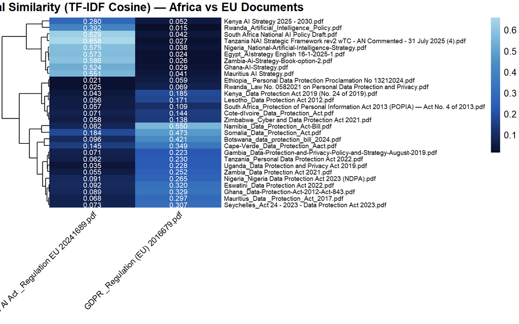

TF-IDF cosine similarity between African and EU documents

```r
# pheatmap requires variance across the matrix values — if all cells are
# identical (which happens with the synthetic placeholder corpus), the colour
# scale breaks are not unique and the function throws an error.
# I check for this before calling pheatmap and fall back to a ggplot tile
# heatmap, which handles flat matrices gracefully.

# sim_matrix is a sparse dgCMatrix from text2vec.
# pheatmap and ggplot both require a dense base R matrix, so I convert
# immediately before any operation on the matrix values.
sim_dense <- as.matrix(sim_matrix)

has_variance <- diff(range(sim_dense, na.rm = TRUE)) > 1e-10
enough_docs  <- nrow(sim_dense) > 0 && ncol(sim_dense) > 0

if (enough_docs && has_variance) {

  do_cluster_rows <- nrow(sim_dense) > 2
  do_cluster_cols <- ncol(sim_dense) > 2

  pheatmap(
    sim_dense,
    color            = heatmap_palette,
    border_color     = NA,
    cluster_rows     = do_cluster_rows,
    cluster_cols     = do_cluster_cols,
    main             = "Lexical Similarity (TF-IDF Cosine) — Africa vs EU Documents",
    fontsize_row     = 7,
    fontsize_col     = 9,
    angle_col        = 45,
    display_numbers  = TRUE,
    number_format    = "%.3f",
    number_color     = "white",
    legend           = TRUE,
    silent           = FALSE
  )

} else if (enough_docs && !has_variance) {

  # Flat matrix fallback when all values are identical.
  sim_long <- as.data.frame(sim_dense) %>%
    rownames_to_column("Africa_doc") %>%
    pivot_longer(-Africa_doc, names_to = "EU_doc", values_to = "similarity")

  ggplot(sim_long, aes(x = EU_doc, y = Africa_doc, fill = similarity)) +
    geom_tile(colour = "white") +
    geom_text(aes(label = round(similarity, 3)), size = 3, colour = "white") +
    scale_fill_gradientn(colours = heatmap_palette, name = "Cosine\nsimilarity") +
    labs(
      title    = "Lexical Similarity (TF-IDF Cosine) — Africa vs EU Documents",
      subtitle = "Note: low variance across values",
      x = "EU documents", y = "African documents"
    ) +
    theme_minimal(base_size = 11) +
    theme(
      axis.text.x      = element_text(angle = 45, hjust = 1, size = 8),
      axis.text.y      = element_text(size = 8),
      plot.title       = element_text(colour = pal$dark1, face = "bold"),
      plot.subtitle    = element_text(colour = pal$mid2, size = 9),
      panel.background = element_rect(fill = pal$neutral, colour = NA)
    )

} else {
  message("Not enough documents to render similarity heatmap.")
}
```

# TF-IDF DISTINCTIVE TERMS PER REGION

Rather than asserting which vocabulary characterises each region, I derive it empirically. I fit TF-IDF treating each region as a single pooled document, then extract the highest-scoring terms. These are the words that are frequent in one region but rare or absent in the other — the terms that most distinctively mark each corpus.

For H1, if African strategies are reproducing EU governance templates, the Africa-distinctive terms should overlap substantially with the EU-distinctive terms. Divergence — particularly if the Africa column is dominated by infrastructural and developmental language while the EU column is dominated by rights, risk, and regulatory terms — would indicate that even where surface-level vocabulary converges, the underlying imaginary is different. This is the empirical grounding for the lexicon categories above.

```r
word_tokens <- df %>%
  select(filename, region, doc_type, clean_text) %>%
  unnest_tokens(word, clean_text) %>%
  anti_join(stop_words, by = "word") %>%
  filter(
    str_detect(word, "^[a-z]{3,}$"),   # only lowercase alpha, min 3 chars
    !str_detect(word, "^[ivxlcdm]+$")  # remove Roman numeral artefacts
  )

# Compute TF-IDF treating each region as a "document"
region_tf_idf <- word_tokens %>%
  count(region, word, name = "n") %>%
  bind_tf_idf(word, region, n) %>%
  arrange(region, desc(tf_idf))

# Extract top 20 terms per region
top_terms <- region_tf_idf %>%
  group_by(region) %>%
  slice_max(tf_idf, n = 20) %>%
  ungroup()

# Display as table
kable(
  top_terms %>%
    select(region, word, n, tf, idf, tf_idf) %>%
    mutate(across(where(is.numeric), ~ round(.x, 4))),
  caption = "Top 20 TF-IDF distinctive terms per region"
) %>%
  kable_styling(bootstrap_options = c("striped", "hover", "condensed"))
```

Top 20 TF-IDF distinctive terms per region

| region | word | n | tf | idf | tf_idf |
| --- | --- | --- | --- | --- | --- |
| Africa | subsection | 777 | 0.0035 | 0.6931 | 0.0024 |
| Africa | gazette | 452 | 0.0020 | 0.6931 | 0.0014 |
| Africa | regulator | 405 | 0.0018 | 0.6931 | 0.0013 |
| Africa | africa | 404 | 0.0018 | 0.6931 | 0.0013 |
| Africa | commissioner | 380 | 0.0017 | 0.6931 | 0.0012 |
| Africa | ghana | 374 | 0.0017 | 0.6931 | 0.0012 |
| Africa | amakuru | 345 | 0.0016 | 0.6931 | 0.0011 |
| Africa | bwite | 334 | 0.0015 | 0.6931 | 0.0010 |
| Africa | strategic | 305 | 0.0014 | 0.6931 | 0.0010 |
| Africa | des | 301 | 0.0014 | 0.6931 | 0.0009 |
| Africa | kenya | 272 | 0.0012 | 0.6931 | 0.0009 |
| Africa | egypt | 256 | 0.0012 | 0.6931 | 0.0008 |
| Africa | cyangwa | 246 | 0.0011 | 0.6931 | 0.0008 |
| Africa | nigeria | 246 | 0.0011 | 0.6931 | 0.0008 |
| Africa | traitement | 243 | 0.0011 | 0.6931 | 0.0008 |
| Africa | south | 233 | 0.0011 | 0.6931 | 0.0007 |
| Africa | minister | 222 | 0.0010 | 0.6931 | 0.0007 |
| Africa | african | 218 | 0.0010 | 0.6931 | 0.0007 |
| Africa | talent | 212 | 0.0010 | 0.6931 | 0.0007 |
| Africa | mauritius | 211 | 0.0010 | 0.6931 | 0.0007 |
| EU | eli | 158 | 0.0025 | 0.6931 | 0.0017 |
| EU | deployers | 109 | 0.0017 | 0.6931 | 0.0012 |
| EU | deployer | 62 | 0.0010 | 0.6931 | 0.0007 |
| EU | prospective | 51 | 0.0008 | 0.6931 | 0.0006 |
| EU | panel | 31 | 0.0005 | 0.6931 | 0.0003 |
| EU | tfeu | 28 | 0.0004 | 0.6931 | 0.0003 |
| EU | asylum | 26 | 0.0004 | 0.6931 | 0.0003 |
| EU | eec | 21 | 0.0003 | 0.6931 | 0.0002 |
| EU | competences | 17 | 0.0003 | 0.6931 | 0.0002 |
| EU | ect | 15 | 0.0002 | 0.6931 | 0.0002 |
| EU | categorisation | 14 | 0.0002 | 0.6931 | 0.0002 |
| EU | importer | 13 | 0.0002 | 0.6931 | 0.0001 |
| EU | secrets | 13 | 0.0002 | 0.6931 | 0.0001 |
| EU | distributor | 12 | 0.0002 | 0.6931 | 0.0001 |
| EU | artificially | 10 | 0.0002 | 0.6931 | 0.0001 |
| EU | emotions | 10 | 0.0002 | 0.6931 | 0.0001 |
| EU | teu | 10 | 0.0002 | 0.6931 | 0.0001 |
| EU | eur | 9 | 0.0001 | 0.6931 | 0.0001 |
| EU | icons | 9 | 0.0001 | 0.6931 | 0.0001 |
| EU | acknowledged | 8 | 0.0001 | 0.6931 | 0.0001 |
| EU | exit | 8 | 0.0001 | 0.6931 | 0.0001 |
| EU | floating | 8 | 0.0001 | 0.6931 | 0.0001 |
| EU | manufacturer | 8 | 0.0001 | 0.6931 | 0.0001 |
| EU | recall | 8 | 0.0001 | 0.6931 | 0.0001 |

# VISUALISATION: DISTINCTIVE TERMS BAR CHART

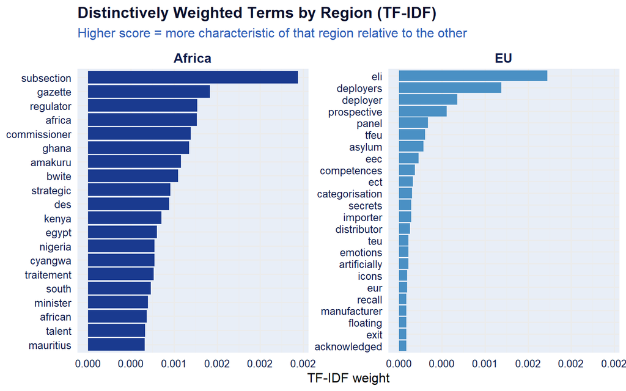

Top TF-IDF distinctive terms per region

```r
top_terms %>%
  mutate(word = reorder_within(word, tf_idf, region)) %>%
  ggplot(aes(x = word, y = tf_idf, fill = region)) +
  geom_col(show.legend = FALSE) +
  scale_fill_manual(values = region_colours) +
  scale_x_reordered() +
  scale_y_continuous(labels = label_number(accuracy = 0.001)) +
  facet_wrap(~ region, scales = "free_y") +
  coord_flip() +
  labs(
    title    = "Distinctively Weighted Terms by Region (TF-IDF)",
    subtitle = "Higher score = more characteristic of that region relative to the other",
    x        = NULL,
    y        = "TF-IDF weight"
  ) +
  theme_minimal(base_size = 12) +
  theme(
    plot.title    = element_text(colour = pal$dark1, face = "bold"),
    plot.subtitle = element_text(colour = pal$mid2),
    strip.text    = element_text(colour = pal$dark2, face = "bold", size = 12),
    axis.text     = element_text(colour = pal$dark2),
    panel.background = element_rect(fill = pal$neutral, colour = NA)
  )
```

# IMAGINARY GAP — OPERATIONALISING THE ASYMMETRY IN H2

The imaginary gap operationalises the core asymmetry H2 predicts. It is defined as: imaginary density minus infrastructural density. A positive gap means a document invests more language in aspirational future-oriented framing than in the material conditions of deployment. A negative or small gap means infrastructural concerns dominate.

H2 predicts that African strategies will have a smaller or negative gap relative to EU instruments because they are written under conditions of material constraint — compute deficits, connectivity gaps, cloud dependency, contested data sovereignty — that EU instruments can afford to assume away. EU acts, by contrast, are written from a position of existing infrastructure and address regulatory architecture rather than material preconditions. I compute the gap at document level and aggregate by region to test this prediction directly.

```r
df_gap <- df_lex %>%
  mutate(
    imaginary_gap = imaginary - infrastructural,
    imaginary_density     = imaginary,
    infrastructural_density = infrastructural
  )

gap_summary <- df_gap %>%
  group_by(region) %>%
  summarise(
    mean_imaginary_density      = mean(imaginary_density,       na.rm = TRUE),
    mean_infrastructural_density = mean(infrastructural_density, na.rm = TRUE),
    mean_imaginary_gap          = mean(imaginary_gap,           na.rm = TRUE),
    sd_imaginary_gap            = sd(imaginary_gap,             na.rm = TRUE),
    n_documents                 = n(),
    .groups = "drop"
  )

kable(
  gap_summary %>% mutate(across(where(is.numeric), ~ round(.x, 5))),
  caption = "Imaginary vs infrastructural density and gap by region"
) %>%
  kable_styling(bootstrap_options = c("striped", "hover"))
```

Imaginary vs infrastructural density and gap by region

| region | mean_imaginary_density | mean_infrastructural_density | mean_imaginary_gap | sd_imaginary_gap | n_documents |
| --- | --- | --- | --- | --- | --- |
| Africa | 0.00584 | 0.00593 | -0.00009 | 0.00521 | 29 |
| EU | 0.00066 | 0.00242 | -0.00176 | 0.00080 | 2 |

# VISUALISATION: IMAGINARY GAP BY REGION

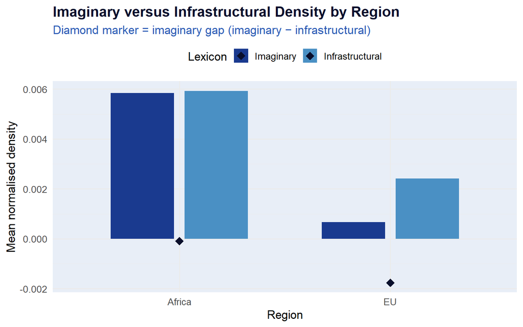

Imaginary vs infrastructural density and gap by region

```r
gap_long <- gap_summary %>%
  pivot_longer(
    cols      = c(mean_imaginary_density, mean_infrastructural_density),
    names_to  = "measure",
    values_to = "value"
  ) %>%
  mutate(
    measure = recode(measure,
      mean_imaginary_density       = "Imaginary",
      mean_infrastructural_density = "Infrastructural"
    )
  )

ggplot(gap_long, aes(x = region, y = value, fill = measure)) +
  geom_col(position = position_dodge(0.7), width = 0.6) +
  geom_point(
    data    = gap_summary,
    mapping = aes(x = region, y = mean_imaginary_gap, fill = NULL),
    colour  = pal$dark1, size = 4, shape = 18
  ) +
  scale_fill_manual(
    values = c("Imaginary" = pal$mid1, "Infrastructural" = pal$light1),
    name   = "Lexicon"
  ) +
  labs(
    title    = "Imaginary versus Infrastructural Density by Region",
    subtitle = "Diamond marker = imaginary gap (imaginary − infrastructural)",
    x        = "Region",
    y        = "Mean normalised density"
  ) +
  theme_minimal(base_size = 13) +
  theme(
    plot.title    = element_text(colour = pal$dark1, face = "bold"),
    plot.subtitle = element_text(colour = pal$mid2),
    legend.position  = "top",
    panel.background = element_rect(fill = pal$neutral, colour = NA)
  )
```

# STATISTICAL TESTS — HYPOTHESIS 1

H1 predicts high lexical convergence between African AI strategies and EU governance frameworks, evidenced by shared governance vocabulary consistent with a Brussels Effect in discursive templates. I operationalise this through two tests:

First, I test whether imaginary lexicon density — the aspirational governance vocabulary that the Brussels Effect is predicted to export — differs significantly between regions. Under H1 I expect the difference to be small, indicating convergence. A large significant difference would challenge H1 because it would mean the two regions are investing in different vocabularies of technological futurity.

Second, I test all six lexicon categories simultaneously using Wilcoxon rank-sum tests (Mann-Whitney U). This non-parametric test is appropriate because policy document corpora are small and the distributions are right-skewed. I report effect size r = Z / sqrt(N) alongside p-values following Grimmer and Stewart (2013) and Laver et al. (2003).

```r
run_wilcox <- function(data, variable, group_var = "region",
                       group1 = "Africa", group2 = "EU") {

  x1 <- data %>% filter(.data[[group_var]] == group1) %>% pull(.data[[variable]])
  x2 <- data %>% filter(.data[[group_var]] == group2) %>% pull(.data[[variable]])

  if (length(x1) < 2 || length(x2) < 2) {
    return(tibble(
      variable  = variable,
      statistic = NA, p_value = NA, effect_r = NA,
      direction = NA, n_africa = length(x1), n_eu = length(x2)
    ))
  }

  wt     <- wilcox.test(x1, x2, exact = FALSE, correct = TRUE)
  n_total <- length(x1) + length(x2)
  effect_r <- abs(qnorm(wt$p.value / 2)) / sqrt(n_total)

  tibble(
    variable  = variable,
    statistic = wt$statistic,
    p_value   = wt$p.value,
    effect_r  = effect_r,
    direction = ifelse(mean(x1, na.rm = TRUE) > mean(x2, na.rm = TRUE),
                       "Africa > EU", "EU > Africa"),
    n_africa  = length(x1),
    n_eu      = length(x2)
  )
}

# Run tests for all lexicon categories
wilcox_results <- purrr::map_dfr(names(LEXICONS), ~ run_wilcox(df_lex, .x))

# Add significance stars for legibility
wilcox_results <- wilcox_results %>%
  mutate(
    sig = case_when(
      p_value < 0.001 ~ "***",
      p_value < 0.01  ~ "**",
      p_value < 0.05  ~ "*",
      p_value < 0.1   ~ ".",
      TRUE            ~ "ns"
    )
  )

kable(
  wilcox_results %>%
    mutate(across(c(statistic, p_value, effect_r), ~ round(.x, 4))),
  caption = "Wilcoxon rank-sum tests: lexicon density differences between Africa and EU"
) %>%
  kable_styling(bootstrap_options = c("striped", "hover")) %>%
  column_spec(4, bold = TRUE)
```

Wilcoxon rank-sum tests: lexicon density differences between Africa and EU

| variable | statistic | p_value | effect_r | direction | n_africa | n_eu | sig |
| --- | --- | --- | --- | --- | --- | --- | --- |
| imaginary | 26 | 0.8407 | 0.0361 | Africa > EU | 29 | 2 | ns |
| infrastructural | 39 | 0.4449 | 0.1372 | Africa > EU | 29 | 2 | ns |
| data | 43 | 0.2777 | 0.1950 | Africa > EU | 29 | 2 | ns |
| rights_ethics | 29 | 1.0000 | 0.0000 | Africa > EU | 29 | 2 | ns |
| development | 28 | 0.9679 | 0.0072 | Africa > EU | 29 | 2 | ns |
| sovereignty | 23 | 0.6583 | 0.0794 | Africa > EU | 29 | 2 | ns |

# STATISTICAL TESTS — HYPOTHESIS 2

H2 predicts that infrastructural imaginaries — references to compute, connectivity, cloud dependency, and sovereignty over technical substrate — will be more prominent in African strategies than in EU instruments, reflecting the asymmetric material conditions under which African governance is articulated. This is a directional hypothesis.

I test it with a one-sided Wilcoxon rank-sum test (alternative = “greater”) so the test is precisely aligned with the theoretical prediction rather than testing a generic difference. The effect size r = Z / sqrt(N) is reported to allow comparison with the H1 tests above and to give a magnitude estimate independent of sample size.

```r
africa_infra <- df_lex %>% filter(region == "Africa") %>% pull(infrastructural)
eu_infra     <- df_lex %>% filter(region == "EU")     %>% pull(infrastructural)

wt_h2 <- wilcox.test(africa_infra, eu_infra,
                     alternative = "greater",
                     exact = FALSE, correct = TRUE)

# Effect size r = Z / sqrt(N).
# qnorm() returns Inf when p = 0 or p = 1 (exact boundary cases with small n).
# I clamp the z-score to a finite value in those cases so the output is clean.
n_h2      <- length(africa_infra) + length(eu_infra)
z_raw     <- qnorm(wt_h2$p.value)
z_h2      <- ifelse(is.finite(z_raw), z_raw, sign(z_raw) * qnorm(0.9999))
effect_h2 <- abs(z_h2) / sqrt(n_h2)

cat("Hypothesis 2 — One-sided Wilcoxon test (Africa > EU on infrastructural):\n")
```

```
## Hypothesis 2 — One-sided Wilcoxon test (Africa > EU on infrastructural):
```

```r
cat(sprintf("  W = %.1f\n", wt_h2$statistic))
```

```
##   W = 39.0
```

```r
cat(sprintf("  p-value (one-sided) = %.4f\n", wt_h2$p.value))
```

```
##   p-value (one-sided) = 0.2225
```

```r
cat(sprintf("  Effect size r = %.4f\n", effect_h2))
```

```
##   Effect size r = 0.1372
```

```r
cat(sprintf("  Mean Africa: %.5f | Mean EU: %.5f\n",
            mean(africa_infra, na.rm = TRUE),
            mean(eu_infra,     na.rm = TRUE)))
```

```
##   Mean Africa: 0.00593 | Mean EU: 0.00242
```

# H1 TARGETED TESTS: AFRICAN AI FRAMEWORKS vs EU AI ACT / AFRICAN DATA ACTS vs GDPR

H1a tests African AI frameworks against the EU AI Act on imaginary vocabulary — the aspirational governance language the Brussels Effect is predicted to export. H1a predicts Africa scores lower because African strategies articulate technological futures through a developmental and infrastructural register rather than reproducing the EU’s frontier imaginary.

H1b tests African data acts against the GDPR on data/DP vocabulary — the regulatory language where the Brussels Effect is most documented. H1b predicts Africa scores higher because GDPR-derived vocabulary (consent, data subject, controller, processing) has diffused into African AI regulatory frameworks through direct legislative borrowing.

```r
# H1 requires two targeted directional comparisons, not a generic
# region × doc_type interaction model. The previous regression produced
# a structurally unestimable interaction (regionEU:doc_typeframework = NA)
# because there are no EU framework documents in this corpus by design.
#
# The correct operationalisation of H1 is:
#
#   Comparison 1 — IMAGINARY vocabulary
#   African AI frameworks  vs  EU AI Act
#   H1a predicts: Africa imaginary < EU imaginary
#   Rationale: African strategies do not reproduce the EU's aspirational
#   futures register because that register assumes existing infrastructure.
#
#   Comparison 2 — DATA / DP vocabulary
#   African data acts  vs  EU GDPR (EU acts)
#   H1b predicts: Africa data > EU data
#   Rationale: GDPR-derived DP vocabulary has diffused into African AI
#   strategies through the Brussels Effect — this is where discursive
#   template adoption is strongest.
#
# I use one-sided Wilcoxon tests aligned precisely with each prediction.

africa_frameworks <- df_lex %>% filter(region == "Africa", doc_type == "framework")
africa_acts       <- df_lex %>% filter(region == "Africa", doc_type == "act")
eu_acts           <- df_lex %>% filter(region == "EU",     doc_type == "act")

# Comparison 1: imaginary density — African AI frameworks vs EU AI Act
wt_imaginary <- wilcox.test(
  africa_frameworks$imaginary,
  eu_acts$imaginary,
  alternative = "less",      # H1a: Africa imaginary < EU
  exact = FALSE, correct = TRUE
)

# Comparison 2: data/DP density — African data acts vs GDPR
wt_data <- wilcox.test(
  africa_acts$data,
  eu_acts$data,
  alternative = "greater",   # H1b: Africa data > EU (Brussels Effect absorption)
  exact = FALSE, correct = TRUE
)

# Effect size r = Z / sqrt(N), clamped against Inf for boundary p-values
safe_effect <- function(p, n) {
  z <- qnorm(p)
  z <- ifelse(is.finite(z), z, sign(z) * qnorm(0.9999))
  abs(z) / sqrt(n)
}

n_c1 <- nrow(africa_frameworks) + nrow(eu_acts)
n_c2 <- nrow(africa_acts)       + nrow(eu_acts)

h1_results <- tibble(
  Comparison  = c(
    "H1a: African AI frameworks vs EU AI Act — imaginary density",
    "H1b: African data acts vs GDPR — data/DP density"
  ),
  Prediction  = c(
    "Africa < EU (imaginary)",
    "Africa > EU (data/DP)"
  ),
  W           = c(wt_imaginary$statistic, wt_data$statistic),
  p_one_sided = c(wt_imaginary$p.value,   wt_data$p.value),
  effect_r    = c(safe_effect(wt_imaginary$p.value, n_c1),
                  safe_effect(wt_data$p.value,      n_c2)),
  mean_Africa = c(
    round(mean(africa_frameworks$imaginary, na.rm = TRUE), 5),
    round(mean(africa_acts$data,            na.rm = TRUE), 5)
  ),
  mean_EU     = c(
    round(mean(eu_acts$imaginary, na.rm = TRUE), 5),
    round(mean(eu_acts$data,      na.rm = TRUE), 5)
  )
) %>%
  mutate(
    sig = case_when(
      p_one_sided < 0.001 ~ "***",
      p_one_sided < 0.01  ~ "**",
      p_one_sided < 0.05  ~ "*",
      p_one_sided < 0.1   ~ ".",
      TRUE                ~ "ns"
    ),
    supported = case_when(
      Comparison == "H1a: African AI frameworks vs EU AI Act — imaginary density" ~
        ifelse(mean_Africa < mean_EU, "Direction correct", "Direction reversed"),
      Comparison == "H1b: African data acts vs GDPR — data/DP density" ~
        ifelse(mean_Africa > mean_EU, "Direction correct", "Direction reversed")
    )
  )

kable(
  h1_results %>% mutate(across(c(W, p_one_sided, effect_r), ~ round(.x, 4))),
  caption = "H1 directional tests: African AI frameworks vs EU AI Act (imaginary) and African data acts vs GDPR (data/DP)"
) %>%
  kable_styling(bootstrap_options = c("striped", "hover", "condensed")) %>%
  column_spec(8, bold = TRUE)
```

H1 directional tests: African AI frameworks vs EU AI Act (imaginary) and African data acts vs GDPR (data/DP)

Comparison

Prediction

W

p_one_sided

effect_r

mean_Africa

mean_EU

sig

supported

H1a: African AI frameworks vs EU AI Act — imaginary density

Africa < EU (imaginary)

18

0.9874

0.6751

0.01810

0.00066

ns

Direction reversed

H1b: African data acts vs GDPR — data/DP density

Africa > EU (data/DP)

36

0.0383

0.3774

0.09509

0.03903

Direction correct

# VISUALISATION: DISTRIBUTION OF KEY LEXICON DENSITIES

The violin plot shows the full distribution shape for the three lexicons most central to H1 and H2: imaginary (H1 convergence test), infrastructural (H2 primary test), and data (H1 Brussels Effect in data governance). Violin width encodes the probability density at each score level. The inner boxplot marks the median and IQR. Individual documents are overlaid as jittered points so that outliers and cluster structure are visible — important in a corpus of 31 documents where individual texts carry weight.

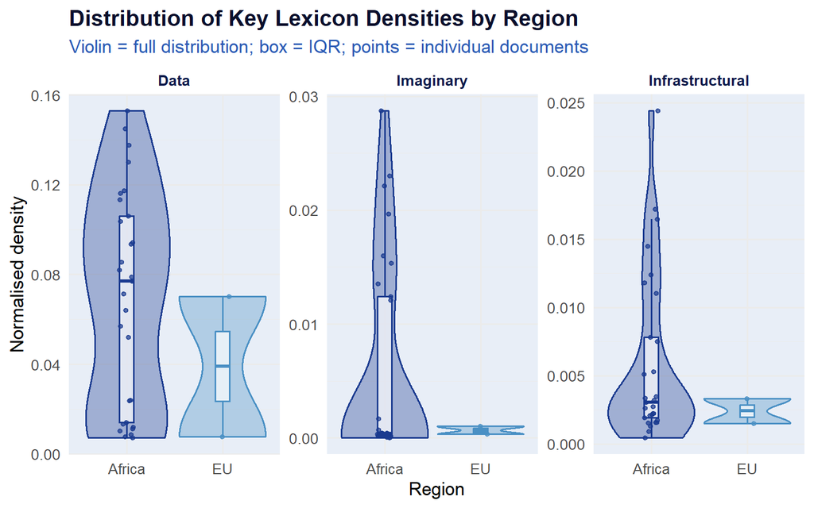

Distribution of lexicon densities by region

```r
df_lex_long <- df_lex %>%
  select(filename, region, doc_type,
         imaginary, infrastructural, data) %>%
  pivot_longer(cols = c(imaginary, infrastructural, data),
               names_to = "lexicon", values_to = "density")

ggplot(df_lex_long, aes(x = region, y = density, fill = region, colour = region)) +
  geom_violin(alpha = 0.35, trim = TRUE, scale = "width") +
  geom_boxplot(width = 0.15, outlier.shape = NA, fill = "white", alpha = 0.7) +
  geom_jitter(width = 0.08, size = 1.2, alpha = 0.7) +
  scale_fill_manual(values   = region_colours, guide = "none") +
  scale_colour_manual(values = region_colours, guide = "none") +
  facet_wrap(~ lexicon, scales = "free_y",
             labeller = labeller(lexicon = c(
               imaginary       = "Imaginary",
               infrastructural = "Infrastructural",
               data            = "Data"
             ))) +
  labs(
    title    = "Distribution of Key Lexicon Densities by Region",
    subtitle = "Violin = full distribution; box = IQR; points = individual documents",
    x        = "Region",
    y        = "Normalised density"
  ) +
  theme_minimal(base_size = 13) +
  theme(
    plot.title       = element_text(colour = pal$dark1, face = "bold"),
    plot.subtitle    = element_text(colour = pal$mid2),
    strip.text       = element_text(colour = pal$dark2, face = "bold"),
    panel.background = element_rect(fill = pal$neutral, colour = NA)
  )
```

# TF-IDF SIMILARITY DECOMPOSED BY DOCUMENT TYPE

H1 concerns visions of technological futures, which are primarily encoded in strategy frameworks rather than in legislative acts. Acts are more procedural and prescriptive; high similarity between African acts and EU acts may simply reflect shared legal drafting conventions rather than genuine discursive template adoption. I therefore decompose average TF-IDF similarity by document type to test whether convergence is stronger in frameworks — where imaginary language is concentrated — than in acts. Under a strong H1, framework similarity should exceed act similarity.

```r
africa_meta <- df[africa_idx, ] %>%
  select(filename, region, doc_type) %>%
  mutate(avg_tfidf_similarity = africa_avg_sim)

sim_by_type <- africa_meta %>%
  group_by(doc_type) %>%
  summarise(
    mean_sim = mean(avg_tfidf_similarity, na.rm = TRUE),
    sd_sim   = sd(avg_tfidf_similarity,   na.rm = TRUE),
    n        = n(),
    .groups  = "drop"
  )

kable(
  sim_by_type %>% mutate(across(where(is.numeric), ~ round(.x, 4))),
  caption = "Mean TF-IDF similarity to EU documents by African document type"
) %>%
  kable_styling(bootstrap_options = c("striped", "hover"))
```

Mean TF-IDF similarity to EU documents by African document type

| doc_type | mean_sim | sd_sim | n |
| --- | --- | --- | --- |
| act | 0.1649 | 0.0798 | 20 |
| framework | 0.2813 | 0.0590 | 9 |

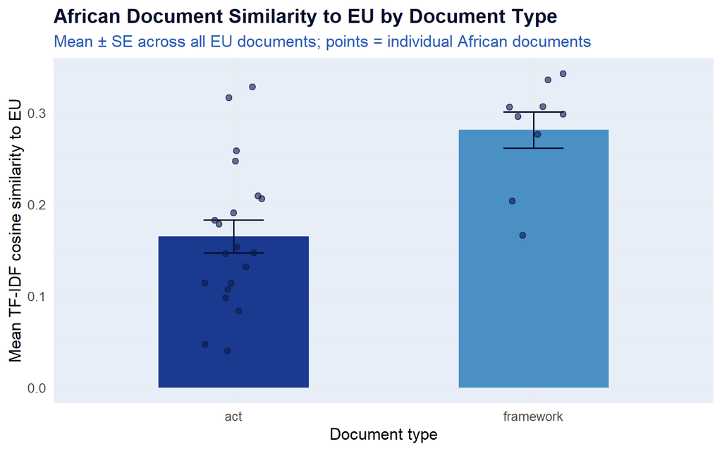

```r
# Bar chart
ggplot(africa_meta,
       aes(x = doc_type, y = avg_tfidf_similarity, fill = doc_type)) +
  geom_col(stat = "summary", fun = "mean", width = 0.5) +
  geom_errorbar(
    stat = "summary", fun.data = mean_se,
    width = 0.2, colour = pal$dark1
  ) +
  geom_jitter(width = 0.1, size = 2, colour = pal$dark2, alpha = 0.6) +
  scale_fill_manual(
    values = c("act" = pal$mid1, "framework" = pal$light1),
    guide  = "none"
  ) +
  labs(
    title    = "African Document Similarity to EU by Document Type",
    subtitle = "Mean ± SE across all EU documents; points = individual African documents",
    x        = "Document type",
    y        = "Mean TF-IDF cosine similarity to EU"
  ) +
  theme_minimal(base_size = 13) +
  theme(
    plot.title       = element_text(colour = pal$dark1, face = "bold"),
    plot.subtitle    = element_text(colour = pal$mid2),
    panel.background = element_rect(fill = pal$neutral, colour = NA)
  )
```

## Data vs Imaginary Density — Quadrant Analysis

This scatter plot provides a joint view of the two central dimensions of H1. The x-axis is imaginary density (the aspirational governance vocabulary H1 predicts will converge) and the y-axis is data density (the regulatory data governance vocabulary H1 predicts the Brussels Effect exports most strongly through GDPR and the Data Act). Documents cluster into quadrants that reveal their imaginary profile. Upper-right documents are high on both — fully converged with the EU regulatory imaginary. Upper-left documents are data-heavy but not imaginary-heavy — technical legal instruments. Lower-right are vision-heavy but not data-governed — aspirational strategies. If H1 holds, African frameworks should cluster near EU documents in this space.

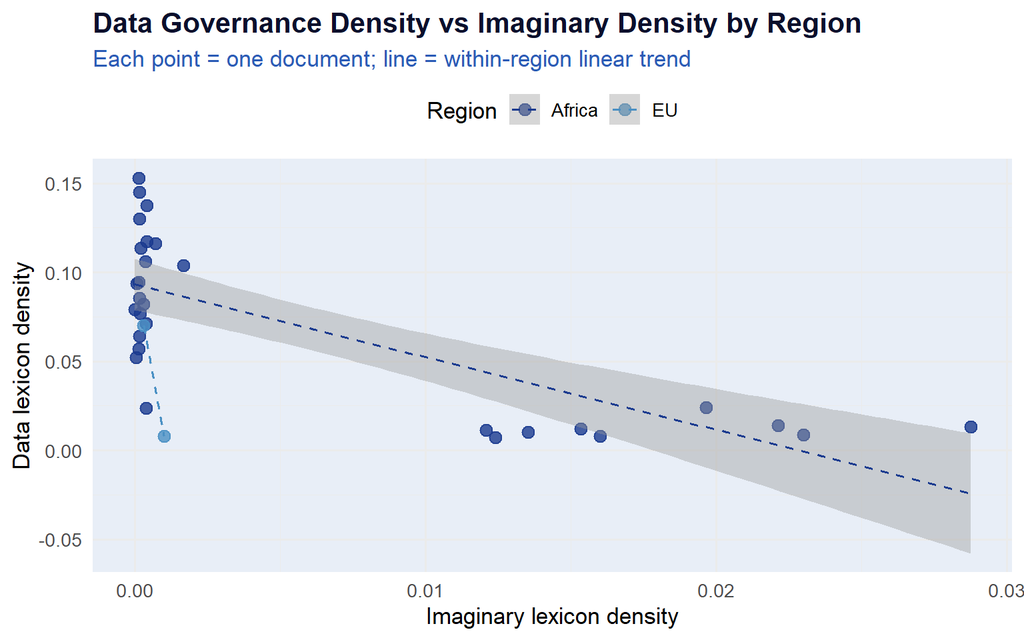

Data density vs imaginary density by region

```r
ggplot(df_lex, aes(x = imaginary, y = data, colour = region, label = filename)) +
  geom_point(size = 3, alpha = 0.8) +
  geom_smooth(method = "lm", se = TRUE, linetype = "dashed", size = 0.7) +
  scale_colour_manual(values = region_colours, name = "Region") +
  labs(
    title    = "Data Governance Density vs Imaginary Density by Region",
    subtitle = "Each point = one document; line = within-region linear trend",
    x        = "Imaginary lexicon density",
    y        = "Data lexicon density"
  ) +
  theme_minimal(base_size = 13) +
  theme(
    plot.title       = element_text(colour = pal$dark1, face = "bold"),
    plot.subtitle    = element_text(colour = pal$mid2),
    legend.position  = "top",
    panel.background = element_rect(fill = pal$neutral, colour = NA)
  )
```

## H1 Extension: N-gram Overlap and Phrase-Level Convergence

H1 specifically claims evidence of shared governance vocabulary and verbatim or near-verbatim n-gram reproduction consistent with Brussels Effect discursive templates. TF-IDF cosine similarity captures general lexical overlap but cannot confirm phrase-level reproduction — two documents could share individual words while using completely different governance phrases.

I test the phrase-level dimension of H1 by extracting bigrams and trigrams from each regional corpus, computing what proportion of EU’s most frequent governance phrases also appear in African documents, and identifying the phrases that are shared versus those exclusive to each corpus. High overlap in governance trigrams (e.g. “artificial intelligence systems”, “risk management framework”, “fundamental rights protection”) would constitute direct evidence of discursive template adoption. Region-exclusive phrases reveal where the two corpora diverge in their framing despite surface lexical similarity.

```r
# I tokenise to bigrams and trigrams separately using tidytext.
# unnest_tokens with token = "ngrams" and n = 2 or 3 produces
# contiguous word sequences. I remove any ngram that contains a
# stop word in either position because function-word sequences
# ("of the", "in a") would dominate and obscure substantive overlap.

bigrams <- df %>%
  select(filename, region, clean_text) %>%
  unnest_tokens(ngram, clean_text, token = "ngrams", n = 2) %>%
  separate(ngram, into = c("w1", "w2"), sep = " ", remove = FALSE) %>%
  filter(!w1 %in% stop_words$word, !w2 %in% stop_words$word) %>%
  select(filename, region, ngram)

trigrams <- df %>%
  select(filename, region, clean_text) %>%
  unnest_tokens(ngram, clean_text, token = "ngrams", n = 3) %>%
  separate(ngram, into = c("w1", "w2", "w3"), sep = " ", remove = FALSE) %>%
  filter(!w1 %in% stop_words$word, !w3 %in% stop_words$word) %>%
  select(filename, region, ngram)

# Frequency tables per region
africa_bigrams <- bigrams %>%
  filter(region == "Africa") %>%
  count(ngram, sort = TRUE) %>%
  mutate(normalised = n / sum(n))

eu_bigrams <- bigrams %>%
  filter(region == "EU") %>%
  count(ngram, sort = TRUE) %>%
  mutate(normalised = n / sum(n))

africa_trigrams <- trigrams %>%
  filter(region == "Africa") %>%
  count(ngram, sort = TRUE) %>%
  mutate(normalised = n / sum(n))

eu_trigrams <- trigrams %>%
  filter(region == "EU") %>%
  count(ngram, sort = TRUE) %>%
  mutate(normalised = n / sum(n))

# Shared ngrams: appear in BOTH Africa and EU corpora
shared_bigrams <- inner_join(
  africa_bigrams %>% rename(n_africa = n, norm_africa = normalised),
  eu_bigrams     %>% rename(n_eu = n,     norm_eu     = normalised),
  by = "ngram"
) %>%
  mutate(mean_freq = (norm_africa + norm_eu) / 2) %>%
  arrange(desc(mean_freq))

shared_trigrams <- inner_join(
  africa_trigrams %>% rename(n_africa = n, norm_africa = normalised),
  eu_trigrams     %>% rename(n_eu = n,     norm_eu     = normalised),
  by = "ngram"
) %>%
  mutate(mean_freq = (norm_africa + norm_eu) / 2) %>%
  arrange(desc(mean_freq))

# Overlap ratio: what proportion of EU's top ngrams also appear in Africa?
eu_top200_bigrams  <- eu_bigrams  %>% slice_max(n, n = 200) %>% pull(ngram)
eu_top200_trigrams <- eu_trigrams %>% slice_max(n, n = 200) %>% pull(ngram)

bigram_overlap_pct  <- mean(eu_top200_bigrams  %in% africa_bigrams$ngram)  * 100
trigram_overlap_pct <- mean(eu_top200_trigrams %in% africa_trigrams$ngram) * 100

cat("Bigram overlap (EU top 200 appearing in Africa):", round(bigram_overlap_pct, 1), "%
")
```

```
## Bigram overlap (EU top 200 appearing in Africa): 58.3 %
```

```r
cat("Trigram overlap (EU top 200 appearing in Africa):", round(trigram_overlap_pct, 1), "%
")
```

```
## Trigram overlap (EU top 200 appearing in Africa): 41.7 %
```

```r
cat("Shared bigrams found:", nrow(shared_bigrams), "
")
```

```
## Shared bigrams found: 2287
```

```r
cat("Shared trigrams found:", nrow(shared_trigrams), "
")
```

```
## Shared trigrams found: 2361
```

```r
# I display the top shared bigrams and trigrams separately.
# These are the specific governance phrases that both corpora use,
# which is the direct evidence H1 requires at the phrase level.

kable(
  head(shared_bigrams, 20) %>%
    mutate(across(where(is.numeric), ~ round(.x, 5))),
  caption = "Top 20 shared bigrams: phrases appearing in both African and EU documents"
) %>%
  kable_styling(bootstrap_options = c("striped", "hover", "condensed"))
```

Top 20 shared bigrams: phrases appearing in both African and EU documents

| ngram | n_africa | norm_africa | n_eu | norm_eu | mean_freq |
| --- | --- | --- | --- | --- | --- |
| personal data | 2669 | 0.02048 | 675 | 0.02595 | 0.02322 |
| ai systems | 201 | 0.00154 | 613 | 0.02357 | 0.01256 |
| data subject | 1680 | 0.01289 | 256 | 0.00984 | 0.01137 |
| ai system | 30 | 0.00023 | 488 | 0.01876 | 0.00950 |
| data protection | 1199 | 0.00920 | 201 | 0.00773 | 0.00846 |
| risk ai | 10 | 0.00008 | 428 | 0.01646 | 0.00827 |
| supervisory authority | 166 | 0.00127 | 328 | 0.01261 | 0.00694 |
| data controller | 1595 | 0.01224 | 9 | 0.00035 | 0.00629 |
| purpose ai | 1 | 0.00001 | 227 | 0.00873 | 0.00437 |
| regulation eu | 1 | 0.00001 | 199 | 0.00765 | 0.00383 |
| natural persons | 17 | 0.00013 | 195 | 0.00750 | 0.00381 |
| data subjects | 308 | 0.00236 | 132 | 0.00508 | 0.00372 |
| ai models | 35 | 0.00027 | 139 | 0.00534 | 0.00281 |
| fundamental rights | 44 | 0.00034 | 135 | 0.00519 | 0.00276 |
| artificial intelligence | 491 | 0.00377 | 36 | 0.00138 | 0.00258 |
| personal information | 640 | 0.00491 | 1 | 0.00004 | 0.00247 |
| european union | 18 | 0.00014 | 122 | 0.00469 | 0.00241 |
| competent authorities | 3 | 0.00002 | 124 | 0.00477 | 0.00240 |
| supervisory authorities | 11 | 0.00008 | 119 | 0.00458 | 0.00233 |
| conformity assessment | 1 | 0.00001 | 113 | 0.00434 | 0.00218 |

```r
kable(
  head(shared_trigrams, 20) %>%
    mutate(across(where(is.numeric), ~ round(.x, 5))),
  caption = "Top 20 shared trigrams: three-word governance phrases shared across regions"
) %>%
  kable_styling(bootstrap_options = c("striped", "hover", "condensed"))
```

Top 20 shared trigrams: three-word governance phrases shared across regions

| ngram | n_africa | norm_africa | n_eu | norm_eu | mean_freq |
| --- | --- | --- | --- | --- | --- |
| risk ai systems | 3 | 0.00002 | 247 | 0.00871 | 0.00437 |
| processing of personal | 482 | 0.00338 | 136 | 0.00480 | 0.00409 |
| rights and freedoms | 138 | 0.00097 | 95 | 0.00335 | 0.00216 |
| controller or processor | 59 | 0.00041 | 106 | 0.00374 | 0.00208 |
| pursuant to article | 1 | 0.00001 | 116 | 0.00409 | 0.00205 |
| accordance with article | 9 | 0.00006 | 108 | 0.00381 | 0.00194 |
| protection of personal | 221 | 0.00155 | 58 | 0.00205 | 0.00180 |
| taking into account | 62 | 0.00043 | 78 | 0.00275 | 0.00159 |
| personal data breach | 142 | 0.00099 | 31 | 0.00109 | 0.00104 |
| data protection officer | 112 | 0.00078 | 31 | 0.00109 | 0.00094 |
| level of protection | 53 | 0.00037 | 39 | 0.00138 | 0.00087 |
| codes of conduct | 60 | 0.00042 | 35 | 0.00123 | 0.00083 |
| categories of personal | 57 | 0.00040 | 33 | 0.00116 | 0.00078 |
| pursuant to paragraph | 2 | 0.00001 | 39 | 0.00138 | 0.00069 |
| data protection impact | 61 | 0.00043 | 27 | 0.00095 | 0.00069 |
| technical and organisational | 55 | 0.00039 | 28 | 0.00099 | 0.00069 |
| protection impact assessment | 55 | 0.00039 | 27 | 0.00095 | 0.00067 |
| european data protection | 1 | 0.00001 | 37 | 0.00130 | 0.00066 |
| personal data protection | 154 | 0.00108 | 5 | 0.00018 | 0.00063 |
| natural or legal | 25 | 0.00018 | 30 | 0.00106 | 0.00062 |

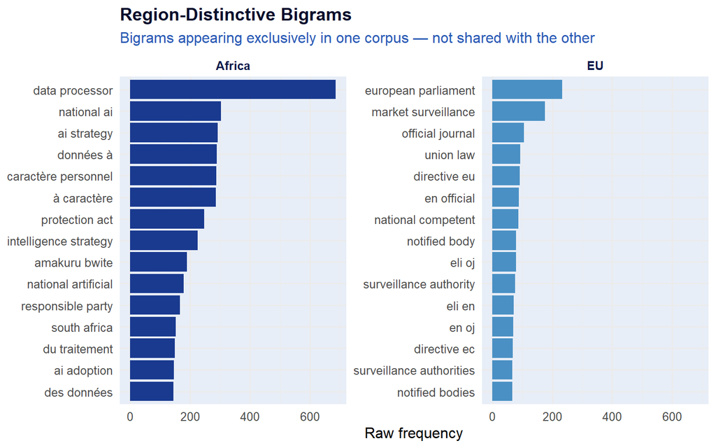

Most distinctive bigrams per region — divergence from shared vocabulary

```r
# I also plot the bigrams most DISTINCTIVE to each region — those that
# appear in one corpus but not the other. This shows where the two
# corpora diverge in their framing, complementing the overlap evidence.

africa_only_bigrams <- africa_bigrams %>%
  filter(!ngram %in% eu_bigrams$ngram) %>%
  slice_max(n, n = 15) %>%
  mutate(region = "Africa")

eu_only_bigrams <- eu_bigrams %>%
  filter(!ngram %in% africa_bigrams$ngram) %>%
  slice_max(n, n = 15) %>%
  mutate(region = "EU")

distinctive_bigrams <- bind_rows(africa_only_bigrams, eu_only_bigrams) %>%
  mutate(ngram = reorder_within(ngram, n, region))

ggplot(distinctive_bigrams, aes(x = ngram, y = n, fill = region)) +
  geom_col(show.legend = FALSE) +
  scale_fill_manual(values = region_colours) +
  scale_x_reordered() +
  coord_flip() +
  facet_wrap(~ region, scales = "free_y") +
  labs(
    title    = "Region-Distinctive Bigrams",
    subtitle = "Bigrams appearing exclusively in one corpus — not shared with the other",
    x        = NULL,
    y        = "Raw frequency"
  ) +
  theme_minimal(base_size = 12) +
  theme(
    plot.title       = element_text(colour = pal$dark1, face = "bold"),
    plot.subtitle    = element_text(colour = pal$mid2),
    strip.text       = element_text(colour = pal$dark2, face = "bold"),
    panel.background = element_rect(fill = pal$neutral, colour = NA)
  )
```

## H2 Extension: KWIC Density for H2 Target Terms

H2 names specific constructs — compute, connectivity, cloud dependency, and sovereignty over technical substrate — as the markers of infrastructural imaginaries in African governance discourse. The lexicon scoring above tests these as aggregate categories. Here I use keyword-in-context (KWIC) analysis to test each construct individually, at the exact surface forms named in the hypothesis, and to examine the documentary contexts in which they appear.

KWIC density (hits per 1000 words) provides a normalised frequency measure that is directly comparable across documents of different lengths. Examining the concordance lines for sovereignty and cloud terms also provides the qualitative grounding that quantitative frequency counts alone cannot offer — showing not just that African strategies mention these terms more, but how they frame them, which is the substance of the infrastructural imaginary argument.

```r
# I build a quanteda corpus from the same clean_text used throughout,
# preserving the region and doc_type metadata as document variables.
# kwic() requires a tokens object; I tokenise without further stemming
# because I want to match the exact surface forms named in H2.

corp_kwic <- quanteda::corpus(
  df,
  text_field = "clean_text",
  docid_field = "filename"
)

quanteda::docvars(corp_kwic, "region")   <- df$region
quanteda::docvars(corp_kwic, "doc_type") <- df$doc_type

toks_kwic <- quanteda::tokens(
  corp_kwic,
  remove_punct   = FALSE,
  remove_numbers = FALSE
)

# H2 target terms — exactly the constructs named in the hypothesis.
# I use glob patterns (*) to capture morphological variants:
# "connect*" captures connectivity, connected, connection etc.
h2_terms <- list(
  compute        = c("comput*", "computing", "computational", "compute"),
  connectivity   = c("connect*", "broadband", "internet access", "bandwidth"),
  cloud          = c("cloud*", "cloud computing", "cloud infrastructure", "cloud dependency"),
  sovereignty    = c("sovereign*", "digital sovereignty", "data sovereignty", "strategic autonomy"),
  infrastructure = c("infrastructur*", "data center*", "server*", "hardware")
)

# Run kwic for each term group and compile results
kwic_results <- purrr::imap_dfr(h2_terms, function(patterns, term_name) {
  purrr::map_dfr(patterns, function(pat) {
    hits <- quanteda::kwic(toks_kwic, pattern = pat, valuetype = "glob", window = 5)
    if (nrow(hits) == 0) return(tibble())
    as_tibble(hits) %>%
      mutate(
        h2_term  = term_name,
        pattern  = pat,
        region   = quanteda::docvars(corp_kwic, "region")[
          match(docname, quanteda::docnames(corp_kwic))
        ],
        doc_type = quanteda::docvars(corp_kwic, "doc_type")[
          match(docname, quanteda::docnames(corp_kwic))
        ]
      )
  })
})

cat("Total KWIC hits across H2 terms:", nrow(kwic_results), "
")
```

```
## Total KWIC hits across H2 terms: 1604
```

```r
print(table(kwic_results$h2_term, kwic_results$region))
```

```
##
##                  Africa  EU
##   cloud             135   1
##   compute           595  25
##   connectivity      245  13
##   infrastructure    513  42
##   sovereignty        35   0
```

```r
# I compute normalised KWIC density: hits per 1000 words per document.
# This allows fair comparison across documents of different lengths.

doc_wordcounts <- df %>%
  mutate(word_count = lengths(str_split(clean_text, "\\s+"))) %>%
  select(filename, word_count, region, doc_type)

kwic_density <- kwic_results %>%
  count(docname, h2_term, region, doc_type, name = "hits") %>%
  left_join(doc_wordcounts, by = c("docname" = "filename",
                                    "region"   = "region",
                                    "doc_type" = "doc_type")) %>%
  mutate(density_per_1000 = hits / word_count * 1000)

# Regional averages per H2 term
kwic_regional <- kwic_density %>%
  group_by(region, h2_term) %>%
  summarise(
    mean_density = mean(density_per_1000, na.rm = TRUE),
    total_hits   = sum(hits),
    n_docs       = n(),
    .groups = "drop"
  )

kable(
  kwic_regional %>%
    pivot_wider(names_from = region,
                values_from = c(mean_density, total_hits, n_docs)) %>%
    mutate(across(where(is.numeric), ~ round(.x, 3))),
  caption = "KWIC density per 1000 words by H2 term and region"
) %>%
  kable_styling(bootstrap_options = c("striped", "hover", "condensed"))
```

KWIC density per 1000 words by H2 term and region

| h2_term | mean_density_Africa | mean_density_EU | total_hits_Africa | total_hits_EU | n_docs_Africa | n_docs_EU |
| --- | --- | --- | --- | --- | --- | --- |
| cloud | 1.015 | 0.011 | 135 | 1 | 9 | 1 |
| compute | 1.649 | 0.151 | 595 | 25 | 21 | 2 |
| connectivity | 0.485 | 0.102 | 245 | 13 | 28 | 2 |
| infrastructure | 1.301 | 0.247 | 513 | 42 | 20 | 2 |
| sovereignty | 0.227 | NA | 35 | NA | 7 | NA |

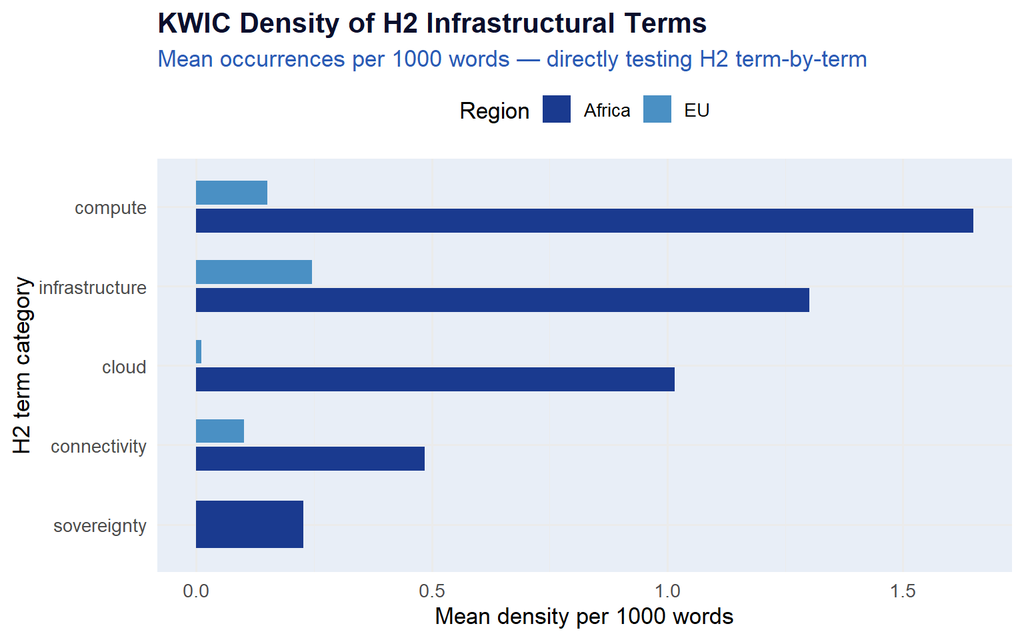

KWIC density for H2 infrastructural terms by region

```r
ggplot(kwic_regional, aes(x = reorder(h2_term, mean_density), y = mean_density, fill = region)) +
  geom_col(position = position_dodge(0.7), width = 0.6) +
  scale_fill_manual(values = region_colours, name = "Region") +
  coord_flip() +
  labs(
    title    = "KWIC Density of H2 Infrastructural Terms",
    subtitle = "Mean occurrences per 1000 words — directly testing H2 term-by-term",
    x        = "H2 term category",
    y        = "Mean density per 1000 words"
  ) +
  theme_minimal(base_size = 13) +
  theme(
    plot.title       = element_text(colour = pal$dark1, face = "bold"),
    plot.subtitle    = element_text(colour = pal$mid2),
    legend.position  = "top",
    panel.background = element_rect(fill = pal$neutral, colour = NA)
  )
```

```r
# I display a sample of raw KWIC concordance lines for the sovereignty
# and cloud terms — the two most theoretically loaded categories.
# This is the qualitative anchor that H1 and H2 both require:
# showing the actual words in their documentary context rather than
# only reporting aggregate statistics.

kwic_sample <- kwic_results %>%
  filter(h2_term %in% c("sovereignty", "cloud")) %>%
  select(docname, region, h2_term, pre, keyword, post) %>%
  group_by(h2_term, region) %>%
  slice_head(n = 5) %>%
  ungroup()

kable(
  kwic_sample,
  caption = "Sample KWIC concordance lines for sovereignty and cloud terms"
) %>%
  kable_styling(bootstrap_options = c("striped", "hover", "condensed"), font_size = 11)
```

Sample KWIC concordance lines for sovereignty and cloud terms

| docname | region | h2_term | pre | keyword | post |
| --- | --- | --- | --- | --- | --- |
| Egypt_AIstrategy English 16-1-2025-1.pdf | Africa | cloud | robust scalable ai infrastructure and | cloud | services innovate business models and |
| Egypt_AIstrategy English 16-1-2025-1.pdf | Africa | cloud | the digital economy and ai | cloud | are the key enablers of |
| Egypt_AIstrategy English 16-1-2025-1.pdf | Africa | cloud | speed connectivity data centers and | cloud | services to enable ai development |
| Egypt_AIstrategy English 16-1-2025-1.pdf | Africa | cloud | robust scalable ai infrastructure and | cloud | services innovate business models and |
| Egypt_AIstrategy English 16-1-2025-1.pdf | Africa | cloud | edge domestic data center intelligent | cloud | computing resource ubiquitous g and |
| EU AI Act _Regulation EU 20241689.pdf | EU | cloud | fire alarm controlling systems in | cloud | computing centres the deployment of |
| Ethiopia_ Personal Data Protection Proclamation No 13212024.pdf | Africa | sovereignty | አለበት ፯ የዳታ ማቀናበር ሕጋዊነት | sovereignty | of the data lawfulness of |
| Ethiopia_ Personal Data Protection Proclamation No 13212024.pdf | Africa | sovereignty | ፳ ፪ የዳታ ሉዓላዊነት data | sovereignty | ፩ እያንዳንዱ የዳታ ተቆጣጣሪ ወይም |
| Nigeria_Nigeria Data Protection Act 2023 (NDPA).pdf | Africa | sovereignty | of data subject or data | sovereignty | without approval of the national |
| Ghana-AI-Strategy.pdf | Africa | sovereignty | ai while guaranteeing african ai | sovereignty | this calls for regional coordination |
| Ghana-AI-Strategy.pdf | Africa | sovereignty | ai while guaranteeing african ai | sovereignty | this calls for regional coordination |